# Calculating the Implied Spread Using Elo

Kyle Bennison

10/6/2021

## Join Historic Elo Ratings with Game Results from 2000-2021

So we have elo ratings from 2000-2021. They include the date of the game, but it’s the date of the game and the elo rating after that game is done. We really want the elo rating before the game’s played, so we’ll join games and elo using the elo of the game before the current game.

```r
slice_sample(elo, n = 10L)
```

```
##               team       conference elo_rating week season                date
##  1:    North Texas   Conference USA   988.2484    7   2015 2015-10-15 23:30:00
##  2:    Boise State    Mountain West  1558.7492    5   2015 2015-10-04 02:15:00
##  3:       Syracuse              ACC  1301.4111   10   2014 2014-11-01 19:00:00
##  4:           UTEP Western Athletic  1041.9158    7   2004 2004-10-10 02:00:00
##  5:  Jackson State                    892.1430    1   2013 2013-08-30 00:00:00
##  6:       Stanford           Pac-12  1680.0822    1   2011 2011-09-03 21:00:00
##  7: North Carolina              ACC  1591.8096   10   2020 2020-11-07 17:00:00
##  8:       Nebraska          Big Ten  1534.8246    0   2014 2014-08-15 00:00:00
##  9:    Idaho State                    945.8840    0   2002 2002-08-15 00:00:00
## 10:        Memphis   Conference USA  1205.2352    2   2002 2002-09-01 00:00:00
```

```r
slice_sample(games, n = 10L)
```

```
## # A tibble: 10 x 30
##           id season  week season_type start_date     start_time_tbd neutral_site
##        <int>  <int> <int> <chr>       <chr>          <lgl>          <lgl>
##  1 253092005   2005    10 regular     2005-11-05T21~ NA             FALSE
##  2 400757022   2015     2 regular     2015-09-12T21~ NA             FALSE
##  3 223200052   2002    13 regular     2002-11-16T20~ NA             FALSE
##  4 292690239   2009     4 regular     2009-09-26T23~ NA             FALSE
##  5     63426   2000     8 regular     2000-10-14T00~ NA             FALSE
##  6 313090277   2011    10 regular     2011-11-05T16~ NA             FALSE
##  7 401013444   2018     9 regular     2018-10-27T23~ NA             FALSE
##  8 282782306   2008     6 regular     2008-10-04T19~ NA             FALSE
##  9 330062032   2012     1 postseason  2013-01-07T02~ NA             TRUE
## 10 212510041   2001     3 regular     2001-09-08T17~ NA             FALSE
## # ... with 23 more variables: conference_game <lgl>, attendance <int>,
## #   venue_id <int>, venue <chr>, home_id <int>, home_team <chr>,
## #   home_conference <chr>, home_points <int>, home_line_scores <list>,
## #   home_post_win_prob <chr>, home_pregame_elo <int>, home_postgame_elo <int>,
## #   away_id <int>, away_team <chr>, away_conference <chr>, away_points <int>,
## #   away_line_scores <list>, away_post_win_prob <chr>, away_pregame_elo <int>,
## #   away_postgame_elo <int>, excitement_index <chr>, highlights <chr>, ...
```

```r
e2 <- elo %>%
  group_by(team) %>%
  mutate(join_date = lead(date, n = 1L, order_by = date))
```

Next, we’ll do the join, joining first for the home teams and then the away teams.

```r
games_elo <- games %>%
  mutate(start_date = lubridate::as_datetime(start_date)) %>%
  left_join(e2, by = c("start_date" = "join_date",
                       "home_team" = "team")) %>%
  left_join(e2, by = c("start_date" = "join_date",
                       "away_team" = "team"),
            suffix = c("_home", "_away"))
```

Now we’ll calculate the difference between the home and away teams in elo rating, including 55 points for the elo spread. Then we’ll calculate the actual spread in these games after they were played.

```r
ge2 <- games_elo %>%
  mutate(home_elo_adv = elo_rating_home + if_else(neutral_site == TRUE, 0, 55) - elo_rating_away,
         final_home_spread = home_points - away_points)
```

## Plotting the relationship

Now let’s look at the relationship between the elo rating differences and the points spread.

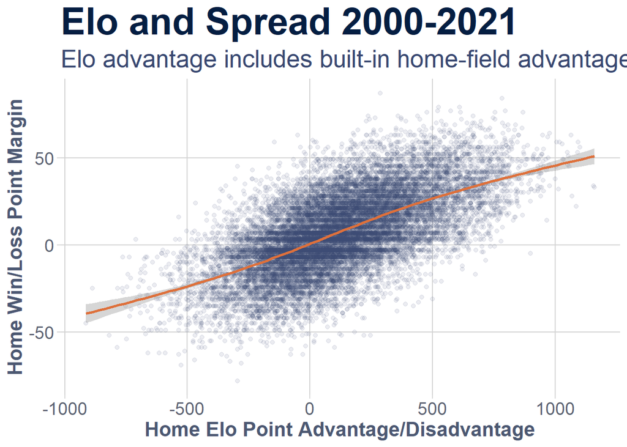

So we definitely have a clear linear relationship here. That’s good. We’re going to have a significant model. However the problem is the variance of the spread. It’s huge. The error on any given spread is going to be really wide. Let’s build the model and see

```r
model <- lm(final_home_spread ~ home_elo_adv, data = ge2)
summary(model)
```

```
##
## Call:
## lm(formula = final_home_spread ~ home_elo_adv, data = ge2)
##
## Residuals:
##    Min     1Q Median     3Q    Max
## -65.54 -11.36   0.00  11.38  71.43
##
## Coefficients:
##               Estimate Std. Error t value Pr(>|t|)
## (Intercept)  0.9097960  0.1449399   6.277 3.53e-10 ***
## home_elo_adv 0.0510737  0.0004808 106.237  < 2e-16 ***
## ---
## Signif. codes:  0 '***' 0.001 '**' 0.01 '*' 0.05 '.' 0.1 ' ' 1
##
## Residual standard error: 17.32 on 17156 degrees of freedom
##   (419 observations deleted due to missingness)
## Multiple R-squared:  0.3968, Adjusted R-squared:  0.3968
## F-statistic: 1.129e+04 on 1 and 17156 DF,  p-value: < 2.2e-16
```

Now let’s use it to see what the predicted spread would be using elo ratings.

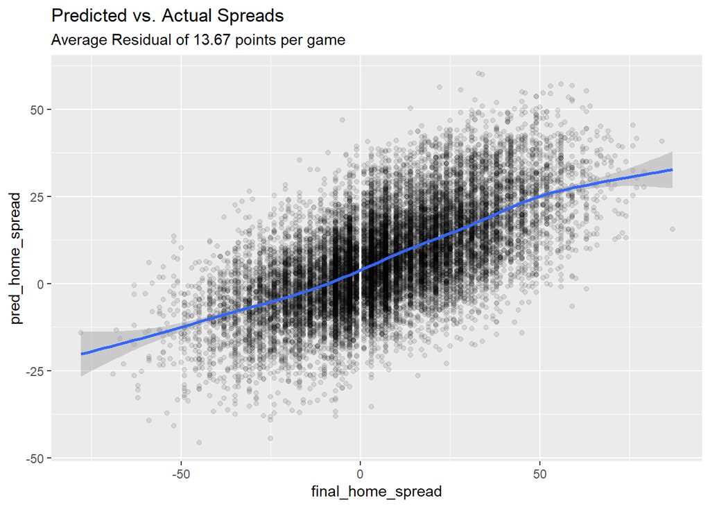

```r
ge_predictions %>%
  ggplot(aes(x = final_home_spread, y = pred_home_spread)) +
  geom_point(alpha = .1) +
  geom_smooth() +
  labs(title = "Predicted vs. Actual Spreads",
       subtitle = paste0("Average Residual of ", round(mean(abs(residuals(model))), 2), " points per game"))
```

So really this is the exact same graph, but we’re just applying the model to the data (and the same data we trained the model on, which is generally a no-no). So even though the model has seen this data before, this is the best it can do given the elo margin, leaving a lot of variability (almost 14 points to be exact.)

So we can’t really use this much unless our spread is > 13 points different from the vegas spread, which should very rarely be the case. And even then, we’d wonder whether vegas knows something we don’t with such a large gap in predictions.